# Stalin

Hitler vs. Stalin:

A Comprehensive Sentiment Analysis According to the Principles of Hannah Arendt

## Introduction + Descriptive Statistics:

#### Download databases

```python
%pip install beautifulsoup4
%pip install requests
%pip install lxml
%pip install pandas
```

```python
import requests
from bs4 import BeautifulSoup
import lxml
import pandas as pd
import requests
from bs4 import BeautifulSoup
import pandas as pd
```

### Retrieving Stalin Data

https://www.marxists.org/reference/archive/stalin/works/decades-index.htm

```python
stalin_source_code = requests.get('https://www.marxists.org/reference/archive/stalin/works/decades-index.htm')
soup = BeautifulSoup(stalin_source_code.content, 'lxml')
stalin_all_the_urls = []

for url in soup.find_all('a'):
    stalin_all_the_urls.append(str(url.get('href')))

stalin_all_the_urls[0:10]
```

```
['../../../../index.htm',
 '../../../../history/ussr/index.htm',
 '../index.htm',
 'collected/index.htm',
 'None',
 '#1900',
 '#1910',
 '#1920',
 '#1930',
 '#1940']
```

#### Here I only chose to keep links with 'htm' in it and '1' to ensure all links are working corrctly

```python
s_url = []
for link in stalin_all_the_urls:
    if link and 'htm' in link and '1' in link:
        s_url.append(link)

#extract'1951/economic-problems/index.htm'
#and  '../../../../archive/sheng/1938/september/02.htm',
# and 1924/foundations-leninism/index.htm',
links_to_remove = [
    '1951/economic-problems/index.htm',
    '../../../../archive/sheng/1938/september/02.htm',
    'correspondence/01/index.htm',
    '1924/foundations-leninism/index.htm'
]

s_url = [link for link in s_url if link not in links_to_remove]
```

##### base url: https://www.marxists.org/reference/archive/stalin/works/

```python
stalin_base_url = 'https://www.marxists.org/reference/archive/stalin/works/'
r_stal = []

for link in s_url:
    r_stal.append(stalin_base_url + link)
```

```python
#takes forever to load
stalin_texts = []

for link in s_url:
  response = requests.get(stalin_base_url + link)
  text = BeautifulSoup(response.content, 'html.parser').get_text()
  stalin_texts.append(text)
```

```python
stalin_docs_df = pd.DataFrame({"url": s_url, "text": stalin_texts, "full_url": r_stal})
stalin_docs_df
```

|  | url | text | full_url |
| --- | --- | --- | --- |
| 0 | 1901/09/x01.htm | \n\n\n\nFrom Editors\n\n\n\n\n\n\n\nJ. V. Stal... | https://www.marxists.org/reference/archive/sta... |
| 1 | 1901/11/x01.htm | \n\nThe Russian Social-Democratic Party and it... | https://www.marxists.org/reference/archive/sta... |
| 2 | 1904/09/01.htm | \n\n\nThe Social-Democratic View on the Nation... | https://www.marxists.org/reference/archive/sta... |
| 3 | 1904/09/x01.htm | \n\n\nA Letter from Kutais\n\n\n\n\n\n\nJ. V. ... | https://www.marxists.org/reference/archive/sta... |
| 4 | 1904/10/x01.htm | \n\n\nA Letter from Kutais\n\n\n\n\n\n\nJ. V. ... | https://www.marxists.org/reference/archive/sta... |
| ... | ... | ... | ... |
| 866 | 1952/09/09.htm | \n\nTelegram to the Chairman of the Council of... | https://www.marxists.org/reference/archive/sta... |
| 867 | 1952/10/01.htm | \n\nTelegram to the Chairman of the Central Pe... | https://www.marxists.org/reference/archive/sta... |
| 868 | 1952/10/07.htm | \n\nTelegram to the Minister President of the ... | https://www.marxists.org/reference/archive/sta... |
| 869 | 1952/10/x01.htm | \n\nTelegram to the Chairman of the Cabinet of... | https://www.marxists.org/reference/archive/sta... |
| 870 | 1952/10/14.htm | \n\nSpeech of the 19th Party Congress of the C... | https://www.marxists.org/reference/archive/sta... |

871 rows × 3 columns

##### The works extracted from the Stalin data base are 871 works

### Retrieving Hitler Data

https://der-fuehrer.org/redenen.htm

```python
hitler_source_code = requests.get('https://der-fuehrer.org/redenen.htm')
soup = BeautifulSoup(hitler_source_code.content, 'lxml')
hitler_all_the_urls = []

for url in soup.find_all('a'):
    hitler_all_the_urls.append(str(url.get('href')))

hitler_all_the_urls[0:10]
```

```
["reden/english/Adolf%20Hitler's%20War%20Directives.pdf",
 'reden/english/wardirectives/directives.html',
 'http://der-fuehrer.org/reden/english/Adolf%20Hitler%20-%20Collection%20of%20Speeches%20-%201922-1945.pdf',
 'reden/english/Adolf%20Hitler-Collection%20of%20Speeches%20and%20Proclamations-1922-1945.pdf',
 "reden/english/Greater%20Germany's%20Battle%20for%20Freedom%20-%20Volume%20I.pdf",
 "reden/english/Greater%20Germany's%20Battle%20for%20Freedom%20-%20Volume%20II.pdf",
 "reden/english/Greater%20Germany's%20Battle%20for%20Freedom%20-%20Volume%20III.pdf",
 'reden/english/Adolf_Hitler_Speaks/f1.htm',
 'reden/english/21-11-09.htm',
 'reden/english/22-04-12.htm']
```

#### Here, I clean Hitler's data in a similar manner

```python
h_url = []
for link in hitler_all_the_urls:
    if link and 'htm' in link:
        h_url.append(link)

links_to_remove = ['reden/english/wardirectives/directives.html',
 'reden/english/Adolf_Hitler_Speaks/f1.htm']

h_url = [link for link in h_url if link not in links_to_remove]
```

```python
hitler_base_url = 'https://der-fuehrer.org/'
r_hitler = []

for link in h_url:
    r_hitler.append(hitler_base_url + link)
```

##### base url: https://der-fuehrer.org/

```python
hitler_texts = []

for link in h_url:
  response = requests.get(hitler_base_url + link)
  text = BeautifulSoup(response.content, 'html.parser').get_text()
  hitler_texts.append(text)
```

```python
hitler_docs_df = pd.DataFrame({"url": h_url, "text": hitler_texts, "full_url": r_hitler})
hitler_docs_df
```

|  | url | text | full_url |
| --- | --- | --- | --- |
| 0 | reden/english/21-11-09.htm | \n\n\n\n\n\n091121\n\n\n\n\nNovember 9, 1921 i... | https://der-fuehrer.org/reden/english/21-11-09... |
| 1 | reden/english/22-04-12.htm | \n\n\n\n\n\n\n\nApril 12, 1922\n\n\n \r\n\n\nA... | https://der-fuehrer.org/reden/english/22-04-12... |
| 2 | reden/english/22-04-12.htm | \n\n\n\n\n\n\n\nApril 12, 1922\n\n\n \r\n\n\nA... | https://der-fuehrer.org/reden/english/22-04-12... |
| 3 | reden/english/22-07-28.htm | \n\n\n\n\nJuly 28, 1922\n\n\n \r\n\n\nJULY 28,... | https://der-fuehrer.org/reden/english/22-07-28... |
| 4 | reden/english/22-09-18.htm | \n\n\n\n\nSeptember 18, 1922\n\n\n\n\n\nSEPTEM... | https://der-fuehrer.org/reden/english/22-09-18... |
| ... | ... | ... | ... |
| 245 | reden/english/45-04-13.htm | \n\n\n\n\n13 April 1945 - Adolf Hitler – order... | https://der-fuehrer.org/reden/english/45-04-13... |
| 246 | reden/english/45-04-13_P.htm | \n\n\n\n\n13 April 1945 - Adolf Hitler – procl... | https://der-fuehrer.org/reden/english/45-04-13... |
| 247 | reden/english/45-04-29_T1.htm | \n\n\n\n\n29 April 1945 - Adolf Hitler - Last ... | https://der-fuehrer.org/reden/english/45-04-29... |
| 248 | reden/english/45-04-29_T2.htm | \n\n\n\n\n29 April 1945 - Adolf Hitler - Priva... | https://der-fuehrer.org/reden/english/45-04-29... |
| 249 | reden/english/45-04-29_M.htm | \n\n\n\n\n29 April 1945 - The marriage license... | https://der-fuehrer.org/reden/english/45-04-29... |

250 rows × 3 columns

##### The works extracted from the Hitler data base are 250 works

### Preprocesing texts

```python
%pip install nltk
```

##### If you do not change this to your suit directory, problems may arise

```python
import nltk
nltk.data.path.append('/Users/libraries/Desktop/help/nltk_data')  # Adjust this path to your system's nltk_data directory
nltk.download('punkt')
nltk.download('punkt_tab')
```

```
True
```

#### Downloading Natural Language Toolkit

```python
from nltk.corpus import stopwords
from nltk.stem import WordNetLemmatizer
import re
```

```python
nltk.download('punkt')
nltk.download('stopwords')
nltk.download('wordnet')
```

```
True
```

#### Token texts auxilary function (this is only for checking purposes)

```python
def token_text(text):
    try:
        return nltk.word_tokenize(text)
    except Exception as e:
        print(f"Error processing text: {e}")
        return []
```

##### Creating the final data frames

```python
stalin_docs_df['tokens'] = stalin_docs_df['text'].apply(token_text)
stalin_docs_df
```

|  | url | text | full_url | tokens |
| --- | --- | --- | --- | --- |
| 0 | 1901/09/x01.htm | \n\n\n\nFrom Editors\n\n\n\n\n\n\n\nJ. V. Stal... | https://www.marxists.org/reference/archive/sta... | [From, Editors, J., V., Stalin, From, Editors,... |
| 1 | 1901/11/x01.htm | \n\nThe Russian Social-Democratic Party and it... | https://www.marxists.org/reference/archive/sta... | [The, Russian, Social-Democratic, Party, and, ... |
| 2 | 1904/09/01.htm | \n\n\nThe Social-Democratic View on the Nation... | https://www.marxists.org/reference/archive/sta... | [The, Social-Democratic, View, on, the, Nation... |
| 3 | 1904/09/x01.htm | \n\n\nA Letter from Kutais\n\n\n\n\n\n\nJ. V. ... | https://www.marxists.org/reference/archive/sta... | [A, Letter, from, Kutais, J., V., Stalin, A, L... |
| 4 | 1904/10/x01.htm | \n\n\nA Letter from Kutais\n\n\n\n\n\n\nJ. V. ... | https://www.marxists.org/reference/archive/sta... | [A, Letter, from, Kutais, J., V., Stalin, A, L... |
| ... | ... | ... | ... | ... |
| 866 | 1952/09/09.htm | \n\nTelegram to the Chairman of the Council of... | https://www.marxists.org/reference/archive/sta... | [Telegram, to, the, Chairman, of, the, Council... |
| 867 | 1952/10/01.htm | \n\nTelegram to the Chairman of the Central Pe... | https://www.marxists.org/reference/archive/sta... | [Telegram, to, the, Chairman, of, the, Central... |
| 868 | 1952/10/07.htm | \n\nTelegram to the Minister President of the ... | https://www.marxists.org/reference/archive/sta... | [Telegram, to, the, Minister, President, of, t... |
| 869 | 1952/10/x01.htm | \n\nTelegram to the Chairman of the Cabinet of... | https://www.marxists.org/reference/archive/sta... | [Telegram, to, the, Chairman, of, the, Cabinet... |
| 870 | 1952/10/14.htm | \n\nSpeech of the 19th Party Congress of the C... | https://www.marxists.org/reference/archive/sta... | [Speech, of, the, 19th, Party, Congress, of, t... |

871 rows × 4 columns

```python
hitler_docs_df['tokens'] = hitler_docs_df['text'].apply(token_text)
hitler_docs_df
```

|  | url | text | full_url | tokens |
| --- | --- | --- | --- | --- |
| 0 | reden/english/21-11-09.htm | \n\n\n\n\n\n091121\n\n\n\n\nNovember 9, 1921 i... | https://der-fuehrer.org/reden/english/21-11-09... | [091121, November, 9, ,, 1921, in, München, Fo... |
| 1 | reden/english/22-04-12.htm | \n\n\n\n\n\n\n\nApril 12, 1922\n\n\n \r\n\n\nA... | https://der-fuehrer.org/reden/english/22-04-12... | [April, 12, ,, 1922, APRIL, 12, ,, 1922, in, M... |
| 2 | reden/english/22-04-12.htm | \n\n\n\n\n\n\n\nApril 12, 1922\n\n\n \r\n\n\nA... | https://der-fuehrer.org/reden/english/22-04-12... | [April, 12, ,, 1922, APRIL, 12, ,, 1922, in, M... |
| 3 | reden/english/22-07-28.htm | \n\n\n\n\nJuly 28, 1922\n\n\n \r\n\n\nJULY 28,... | https://der-fuehrer.org/reden/english/22-07-28... | [July, 28, ,, 1922, JULY, 28, ,, 1922, in, Mun... |
| 4 | reden/english/22-09-18.htm | \n\n\n\n\nSeptember 18, 1922\n\n\n\n\n\nSEPTEM... | https://der-fuehrer.org/reden/english/22-09-18... | [September, 18, ,, 1922, SEPTEMBER, 18, ,, 192... |
| ... | ... | ... | ... | ... |
| 245 | reden/english/45-04-13.htm | \n\n\n\n\n13 April 1945 - Adolf Hitler – order... | https://der-fuehrer.org/reden/english/45-04-13... | [13, April, 1945, -, Adolf, Hitler, –, order, ... |
| 246 | reden/english/45-04-13_P.htm | \n\n\n\n\n13 April 1945 - Adolf Hitler – procl... | https://der-fuehrer.org/reden/english/45-04-13... | [13, April, 1945, -, Adolf, Hitler, –, proclam... |
| 247 | reden/english/45-04-29_T1.htm | \n\n\n\n\n29 April 1945 - Adolf Hitler - Last ... | https://der-fuehrer.org/reden/english/45-04-29... | [29, April, 1945, -, Adolf, Hitler, -, Last, P... |
| 248 | reden/english/45-04-29_T2.htm | \n\n\n\n\n29 April 1945 - Adolf Hitler - Priva... | https://der-fuehrer.org/reden/english/45-04-29... | [29, April, 1945, -, Adolf, Hitler, -, Private... |
| 249 | reden/english/45-04-29_M.htm | \n\n\n\n\n29 April 1945 - The marriage license... | https://der-fuehrer.org/reden/english/45-04-29... | [29, April, 1945, -, The, marriage, license, o... |

250 rows × 4 columns

#### Preprocesing texts auxilary function (this is the foundation of the follwing analysis)

```python
def preprocess_text(text):
    words_remove = ['adolf', 'hitler', 'internet', 'copyright', 'mia', 'markup', 'index', 'volume', 'make',
                    'derivative', 'commercial','source', 'credit', 'source', 'display', 'perform',
                    'derivative', 'commercial', 'copy', 'languages', 'adolph', 'hitler', 'stalin']
    try:
        text = text.lower()
        text = re.sub(r'[^a-zA-Z\s]', '', text)
        tokens = nltk.word_tokenize(text)
        stop_words = set(stopwords.words('english'))
        tokens = [word for word in tokens if word not in stop_words]

        # Lemmatization
        lemmatizer = WordNetLemmatizer()
        tokens = [lemmatizer.lemmatize(word) for word in tokens]
        tokens = [word for word in tokens if len(word) >= 2]
        tokens = [word for word in tokens if word not in words_remove]

        return tokens
    except Exception as e:
        print(f"Error processing text: {e}")
        return []
```

```python
stalin_docs_df['tokens'] = stalin_docs_df['text'].apply(preprocess_text)
stalin_docs_df.iloc[0]['tokens'][30:40] #check if it works
```

```
['intelligent',
 'georgian',
 'reader',
 'publication',
 'free',
 'periodical',
 'urgent',
 'question',
 'convinced',
 'question']
```

```python
hitler_docs_df['tokens'] = hitler_docs_df['text'].apply(preprocess_text)
hitler_docs_df.iloc[0]['tokens'][0:10] #check if it works
```

```
['november',
 'mnchen',
 'two',
 'possibility',
 'either',
 'remain',
 'german',
 'come',
 'thumb',
 'jew']
```

## Quantitative Summary

```python
%pip install scikit-learn
%pip install matplotlib
```

```python
from sklearn.feature_extraction.text import CountVectorizer
import matplotlib.pyplot as plt
from sklearn.metrics.pairwise import cosine_similarity
import random
import numpy as np
```

```python
vectorizer = CountVectorizer(encoding= 'ISO-8859-1',
                             stop_words='english',
                             min_df = 1,
                             decode_error='ignore')

# I am creating an input stream from the tokens lists
hitler_docs_df['joined_tokens'] = hitler_docs_df['tokens'].apply(lambda x: ' '.join(x))
stalin_docs_df['joined_tokens'] = stalin_docs_df['tokens'].apply(lambda x: ' '.join(x))
```

##### Create the document-term matrix (dtm) and a vocabulary list (vocab) from the joined tokens I created

```python
hitler_dtm = vectorizer.fit_transform(hitler_docs_df['joined_tokens'])
hitler_vocab = vectorizer.get_feature_names_out()
```

```python
print(type(hitler_vocab))
print(len(hitler_vocab))
print(hitler_vocab)
print(hitler_dtm.shape)
```

```
<class 'numpy.ndarray'>
16110
['aa' 'aachen' 'abandon' ... 'zuchtung' 'zulu' 'zuruckgeschossen']
(250, 16110)
```

```python
stalin_dtm = vectorizer.fit_transform(stalin_docs_df['joined_tokens'])
stalin_vocab = vectorizer.get_feature_names_out()
```

```python
print(type(stalin_vocab))
print(len(stalin_vocab))
print(stalin_vocab)
print(stalin_dtm.shape)
```

```
<class 'numpy.ndarray'>
25080
['aa' 'ab' 'abandon' ... 'zvezdas' 'zyablikov' 'zykov']
(871, 25080)
```

#### Finding the 20 most common words for each leader

```python
# This finds the frequency of each word by summing all occurances
hitler_dtm = np.sum(hitler_dtm.toarray(), axis=0)
stalin_dtm = np.sum(stalin_dtm.toarray(), axis=0)

print(hitler_dtm)
print(stalin_dtm)
```

```
[ 1  4 33 ...  1  2  1]
[14  9 88 ...  1  2  1]
```

```python
# Create DataFrame
hitler_dtm_df = pd.DataFrame({'Word': hitler_vocab, 'n': hitler_dtm})
stalin_dtm_df = pd.DataFrame({'Word': stalin_vocab, 'n': stalin_dtm})

# Sort
hitler_dtm_df = hitler_dtm_df.sort_values(by='n', ascending=False)
stalin_dtm_df = stalin_dtm_df.sort_values(by='n', ascending=False)
```

##### Make plots for each

```python
# I had to add this after it took to long to run the plot.
hitler_dtm_df20 = hitler_dtm_df.sort_values(by='n', ascending=False).head(20)
stalin_dtm_df20 = stalin_dtm_df.sort_values(by='n', ascending=False).head(20)
```

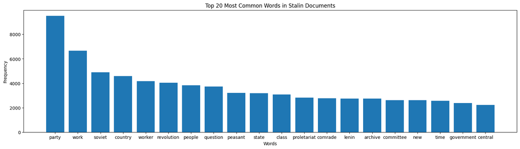

```python
# Plot Stalin's Top 20 Words
plt.figure(figsize=(20, 5))
plt.bar(stalin_dtm_df20['Word'], stalin_dtm_df20['n'])
plt.title("Top 20 Most Common Words in Stalin Documents")
plt.xlabel("Words")
plt.ylabel("Frequency")
plt.show()
```

#### Now I wasnt to find Top 20 Most Common Words in Stalin Documents Compared to Hitler

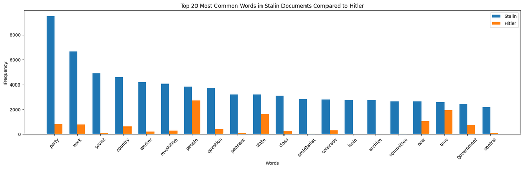

```python
comparison_df20 = pd.merge(stalin_dtm_df20, hitler_dtm_df, on='Word', how='left', suffixes=('_Stalin', '_Hitler')).fillna(0)
x = np.arange(len(comparison_df20))
plt.figure(figsize=(20, 5))
width = 0.35  # Width of the bars

plt.bar(x - width/2, comparison_df20['n_Stalin'], width=width, label='Stalin')
plt.bar(x + width/2, comparison_df20['n_Hitler'], width=width, label='Hitler')
plt.title("Top 20 Most Common Words in Stalin Documents Compared to Hitler")
plt.xlabel("Words")
plt.ylabel("Frequency")
plt.xticks(x, comparison_df20['Word'], rotation=45)
plt.legend()
plt.show()
```

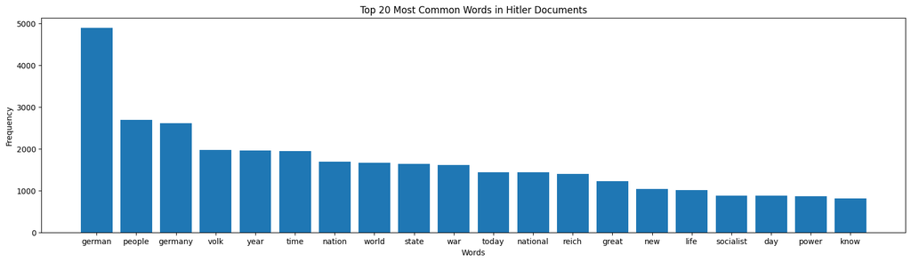

```python
# Plot Hitler's Top 20 Words
plt.figure(figsize=(20, 5))
plt.bar(hitler_dtm_df20['Word'], hitler_dtm_df20['n'])
plt.title("Top 20 Most Common Words in Hitler Documents")
plt.xlabel("Words")
plt.ylabel("Frequency")
plt.show()
```

#### Now I want to find Top 20 Most Common Words in Hitler Documents Compared to Stalin

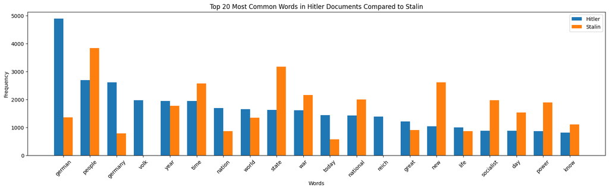

```python
#TWEAKED FROM CODE ABOVE
comparison_df20 = pd.merge(hitler_dtm_df20, stalin_dtm_df, on='Word', how='left', suffixes=('_Hitler', '_Stalin')).fillna(0)

plt.figure(figsize=(20, 5))
plt.bar(x - width/2, comparison_df20['n_Hitler'], width=width, label='Hitler')  # Hitler's bars
plt.bar(x + width/2, comparison_df20['n_Stalin'], width=width, label='Stalin')  # Stalin's bars
plt.title("Top 20 Most Common Words in Hitler Documents Compared to Stalin")
plt.xlabel("Words")
plt.ylabel("Frequency")
plt.xticks(x, comparison_df20['Word'], rotation=45)
plt.legend()
plt.show()
```

##### This is done by merging the repective df's and comparing frequencies of the combined top words

```python
#merge and drop duplicates
comparison_df = pd.merge(hitler_dtm_df, stalin_dtm_df, on='Word')
comparison_df = comparison_df.drop_duplicates(subset='Word')
comparison_df = comparison_df.rename(columns={'n_x': 'Hitler', 'n_y': 'Stalin'})
comparison_df
```

|  | Word | Hitler | Stalin |
| --- | --- | --- | --- |
| 0 | german | 4890 | 1360 |
| 1 | people | 2690 | 3835 |
| 2 | germany | 2613 | 788 |
| 3 | year | 1952 | 1777 |
| 4 | time | 1942 | 2572 |
| ... | ... | ... | ... |
| 9798 | jumble | 1 | 3 |
| 9799 | junction | 1 | 93 |
| 9800 | junk | 1 | 1 |
| 9801 | jubilant | 1 | 3 |
| 9802 | jolt | 1 | 1 |

9803 rows × 3 columns

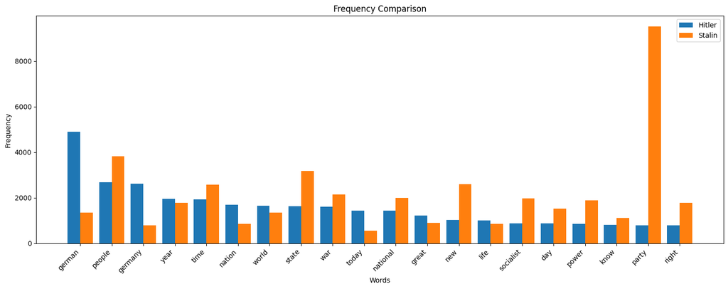

```python
# Plot
comparison_df = comparison_df.head(20)
# Define bar width and x positions
x = np.arange(len(comparison_df['Word']))  # X positions for words
width = 0.4  # Width of each bar

# Plot
plt.figure(figsize=(15, 6))  # Adjust figure size
plt.bar(x - width/2, comparison_df['Hitler'], width=width, label='Hitler')  # Shift bars for Hitler
plt.bar(x + width/2, comparison_df['Stalin'], width=width, label='Stalin')  # Shift bars for Stalin

# Formatting
plt.title("Frequency Comparison")
plt.xlabel("Words")
plt.ylabel("Frequency")
plt.xticks(x, comparison_df['Word'], rotation=45, ha="right")  # Set x-axis labels
plt.legend()

# Show the plot
plt.tight_layout()
plt.show()
```

#### COSINE SIMILARITY

##### Cosine analysis on 50 random documents

```python
def compute_avg_similarity(indices1, indices2, cosine_sim_matrix, within_group=True):
    total_sum = 0
    count = 0

    for i in indices1:
        for j in indices2:
            if within_group and i == j:
                continue
            total_sum += cosine_sim_matrix[i, j]
            count += 1

    return total_sum / count if count > 0 else 0
```

#### Here I compared Hitler with Stalin then each to themselves to measure redundancy

```
Average Cosine Similarity Within Hitler's Speeches: 0.3592745965878886
Average Cosine Similarity Within Stalin's Speeches: 0.17011667735036345
Average Cosine Similarity Between Hitler's and Stalin's Speeches: 0.11696984257422038
```

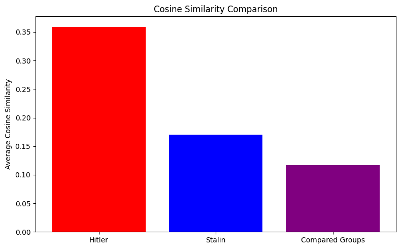

```python
#Random sample of 50
hitler_sample = hitler_docs_df['joined_tokens'].sample(n=50, random_state=None).tolist()
stalin_sample = stalin_docs_df['joined_tokens'].sample(n=50, random_state=None).tolist()
combined_corpus = hitler_sample + stalin_sample

# Math
vectorizer = CountVectorizer()
dtm = vectorizer.fit_transform(combined_corpus)
cosine_sim_matrix = cosine_similarity(dtm, dtm)

# Split indices for the two leaders so we can compare within and between groups
hitler_indices = range(0, 50)
stalin_indices = range(50, 100)
#calculate
hitler_self = compute_avg_similarity(hitler_indices, hitler_indices, cosine_sim_matrix, within_group=True)
stalin_self = compute_avg_similarity(stalin_indices, stalin_indices, cosine_sim_matrix, within_group=True)
hit_stal = compute_avg_similarity(hitler_indices, stalin_indices, cosine_sim_matrix, within_group=False)

print("Average Cosine Similarity Within Hitler's Speeches:", hitler_self)
print("Average Cosine Similarity Within Stalin's Speeches:", stalin_self)
print("Average Cosine Similarity Between Hitler's and Stalin's Speeches:", hit_stal)

# Plot the results
labels = ['Hitler', 'Stalin', 'Compared Groups']
values = [hitler_self, stalin_self, hit_stal]

plt.figure(figsize=(8, 5))
plt.bar(labels, values, color=['red', 'blue', 'purple'])
plt.title("Cosine Similarity Comparison")
plt.ylabel("Average Cosine Similarity")
plt.tight_layout()
plt.show()
```

## Refining your model

```
Average Cosine Similarity Within Hitler's Speeches: 0.35166821361529993
Average Cosine Similarity Within Stalin's Speeches: 0.20370687088250455
Average Cosine Similarity Between Hitler's and Stalin's Speeches: 0.10547312608490882
```

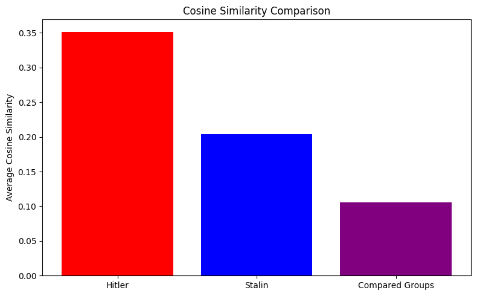

```python
#Random sample of 50
hitler_sample = hitler_docs_df['joined_tokens'].sample(n=50, random_state=None).tolist()
stalin_sample = stalin_docs_df['joined_tokens'].sample(n=50, random_state=None).tolist()
combined_corpus = hitler_sample + stalin_sample

# Math
vectorizer = CountVectorizer()
dtm = vectorizer.fit_transform(combined_corpus)
cosine_sim_matrix = cosine_similarity(dtm, dtm)

# Split indices for the two leaders so we can compare within and between groups
hitler_indices = range(0, 50)
stalin_indices = range(50, 100)
#calculate
hitler_self = compute_avg_similarity(hitler_indices, hitler_indices, cosine_sim_matrix, within_group=True)
stalin_self = compute_avg_similarity(stalin_indices, stalin_indices, cosine_sim_matrix, within_group=True)
hit_stal = compute_avg_similarity(hitler_indices, stalin_indices, cosine_sim_matrix, within_group=False)

print("Average Cosine Similarity Within Hitler's Speeches:", hitler_self)
print("Average Cosine Similarity Within Stalin's Speeches:", stalin_self)
print("Average Cosine Similarity Between Hitler's and Stalin's Speeches:", hit_stal)

# Plot the results
labels = ['Hitler', 'Stalin', 'Compared Groups']
values = [hitler_self, stalin_self, hit_stal]

plt.figure(figsize=(8, 5))
plt.bar(labels, values, color=['red', 'blue', 'purple'])
plt.title("Cosine Similarity Comparison")
plt.ylabel("Average Cosine Similarity")
plt.tight_layout()
plt.show()
```

```
Average Cosine Similarity Within Hitler's Speeches: 0.33662998943894096
Average Cosine Similarity Within Stalin's Speeches: 0.1973939777368421
Average Cosine Similarity Between Hitler's and Stalin's Speeches: 0.10947763910415959
```

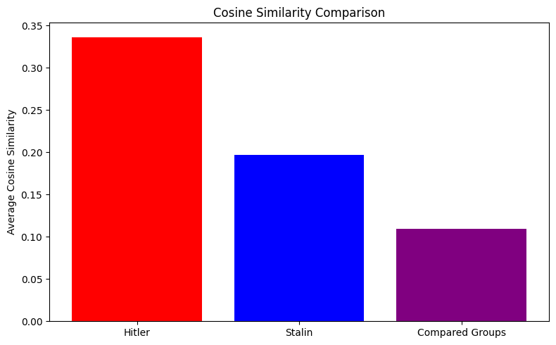

```python
#Random sample of 50
hitler_sample = hitler_docs_df['joined_tokens'].sample(n=100, random_state=None).tolist()
stalin_sample = stalin_docs_df['joined_tokens'].sample(n=100, random_state=None).tolist()
combined_corpus = hitler_sample + stalin_sample

# Math
vectorizer = CountVectorizer()
dtm = vectorizer.fit_transform(combined_corpus)
cosine_sim_matrix = cosine_similarity(dtm, dtm)

# Split indices for the two leaders so we can compare within and between groups
hitler_indices = range(0, 100)
stalin_indices = range(100, 200)
#calculate
hitler_self = compute_avg_similarity(hitler_indices, hitler_indices, cosine_sim_matrix, within_group=True)
stalin_self = compute_avg_similarity(stalin_indices, stalin_indices, cosine_sim_matrix, within_group=True)
hit_stal = compute_avg_similarity(hitler_indices, stalin_indices, cosine_sim_matrix, within_group=False)

print("Average Cosine Similarity Within Hitler's Speeches:", hitler_self)
print("Average Cosine Similarity Within Stalin's Speeches:", stalin_self)
print("Average Cosine Similarity Between Hitler's and Stalin's Speeches:", hit_stal)

# Plot the results
labels = ['Hitler', 'Stalin', 'Compared Groups']
values = [hitler_self, stalin_self, hit_stal]

plt.figure(figsize=(8, 5))
plt.bar(labels, values, color=['red', 'blue', 'purple'])
plt.title("Cosine Similarity Comparison")
plt.ylabel("Average Cosine Similarity")
plt.tight_layout()
plt.show()
```

```
Average Cosine Similarity Within Hitler's Speeches: 0.33505345503721484
Average Cosine Similarity Within Stalin's Speeches: 0.18918214070701594
Average Cosine Similarity Between Hitler's and Stalin's Speeches: 0.11955384630982185
```

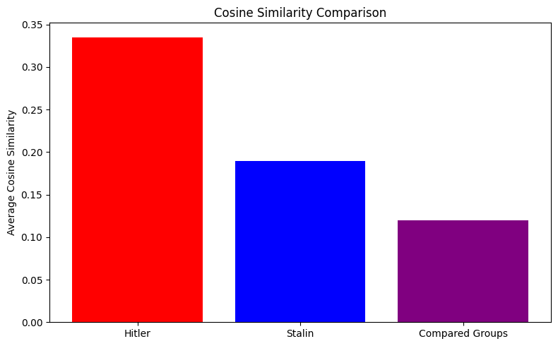

```python
#Random sample of 50
hitler_sample = hitler_docs_df['joined_tokens'].sample(n=200, random_state=None).tolist()
stalin_sample = stalin_docs_df['joined_tokens'].sample(n=200, random_state=None).tolist()
combined_corpus = hitler_sample + stalin_sample

# Math
vectorizer = CountVectorizer()
dtm = vectorizer.fit_transform(combined_corpus)
cosine_sim_matrix = cosine_similarity(dtm, dtm)

# Split indices for the two leaders so we can compare within and between groups
hitler_indices = range(0, 200)
stalin_indices = range(200, 400)
#calculate
hitler_self = compute_avg_similarity(hitler_indices, hitler_indices, cosine_sim_matrix, within_group=True)
stalin_self = compute_avg_similarity(stalin_indices, stalin_indices, cosine_sim_matrix, within_group=True)
hit_stal = compute_avg_similarity(hitler_indices, stalin_indices, cosine_sim_matrix, within_group=False)

print("Average Cosine Similarity Within Hitler's Speeches:", hitler_self)
print("Average Cosine Similarity Within Stalin's Speeches:", stalin_self)
print("Average Cosine Similarity Between Hitler's and Stalin's Speeches:", hit_stal)

# Plot the results
labels = ['Hitler', 'Stalin', 'Compared Groups']
values = [hitler_self, stalin_self, hit_stal]

plt.figure(figsize=(8, 5))
plt.bar(labels, values, color=['red', 'blue', 'purple'])
plt.title("Cosine Similarity Comparison")
plt.ylabel("Average Cosine Similarity")
plt.tight_layout()
plt.show()
```

## Modeling Text and Sentiment analysis

```python
%pip install numpy
%pip install gensim
%pip install vaderSentiment
```

```python
%pip install nltk
```

```python
from vaderSentiment.vaderSentiment import SentimentIntensityAnalyzer

# Initialize VADER
analyzer = SentimentIntensityAnalyzer()

from gensim import corpora, models

from itertools import chain
from nltk import FreqDist
```

#### Recreation of dictionaries for the purposes of machine learning

```python
stalin_docs_df.head(10)
```

|  | url | text | full_url | tokens | joined_tokens |
| --- | --- | --- | --- | --- | --- |
| 0 | 1901/09/x01.htm | \n\n\n\nFrom Editors\n\n\n\n\n\n\n\nJ. V. Stal... | https://www.marxists.org/reference/archive/sta... | [editor, editor, september, work, vol, novembe... | editor editor september work vol november apri... |
| 1 | 1901/11/x01.htm | \n\nThe Russian Social-Democratic Party and it... | https://www.marxists.org/reference/archive/sta... | [russian, socialdemocratic, party, immediate, ... | russian socialdemocratic party immediate task ... |
| 2 | 1904/09/01.htm | \n\n\nThe Social-Democratic View on the Nation... | https://www.marxists.org/reference/archive/sta... | [socialdemocratic, view, national, question, s... | socialdemocratic view national question social... |
| 3 | 1904/09/x01.htm | \n\n\nA Letter from Kutais\n\n\n\n\n\n\nJ. V. ... | https://www.marxists.org/reference/archive/sta... | [letter, kutais, letter, kutais, septemberocto... | letter kutais letter kutais septemberoctober w... |
| 4 | 1904/10/x01.htm | \n\n\nA Letter from Kutais\n\n\n\n\n\n\nJ. V. ... | https://www.marxists.org/reference/archive/sta... | [letter, kutais, letter, kutais, comrade, octo... | letter kutais letter kutais comrade october wo... |
| 5 | 1905/01/01.htm | \n\n\nThe Proletarian Class and The Proletaria... | https://www.marxists.org/reference/archive/sta... | [proletarian, class, proletarian, party, prole... | proletarian class proletarian party proletaria... |
| 6 | 1905/01/x01.htm | \n\n\nWorkers of the Caucasus, it is Time to T... | https://www.marxists.org/reference/archive/sta... | [worker, caucasus, time, take, revenge, worker... | worker caucasus time take revenge worker cauca... |
| 7 | 1905/02/13.htm | \n\n\nLong Live International Fraternity !\n\n... | https://www.marxists.org/reference/archive/sta... | [long, live, international, fraternity, long, ... | long live international fraternity long live i... |
| 8 | 1905/02/15.htm | \n\n\nTo Citizens Long Live The Red Flag !\n\n... | https://www.marxists.org/reference/archive/sta... | [citizen, long, live, red, flag, citizen, long... | citizen long live red flag citizen long live r... |
| 9 | 1905/05/x01.htm | \n\n\nBriefly About Disagreements in the Party... | https://www.marxists.org/reference/archive/sta... | [briefly, disagreement, party, briefly, disagr... | briefly disagreement party briefly disagreemen... |

```python
# Create dictionaries for Stalin and Hitler speeches
stalin_dict = corpora.Dictionary(stalin_docs_df['tokens'])
hitler_dict = corpora.Dictionary(hitler_docs_df['tokens'])

# Create Bag of Words
stalin_corpus = [stalin_dict.doc2bow(text) for text in stalin_docs_df['tokens']]
hitler_corpus = [hitler_dict.doc2bow(text) for text in hitler_docs_df['tokens']]
```

##### Latent Dirichlet Allocation (LDA) -> unsupervised learning

```python
# Stalin's LDA model
stalin_lda = models.LdaModel(
    corpus=stalin_corpus,
    id2word=stalin_dict,
    num_topics=10,
    random_state=100,
    update_every=1,
    chunksize=50,
    passes=50,
    alpha=0.01,
    eta=0.01,
    iterations=50,
    per_word_topics=True
)
```

##### Stalin top 10 Topics Using Latent Dirichlet Allocation

```python
# Stalin's topics
print("Stalin's Topics:")
for idx, topic in stalin_lda.print_topics(num_topics=10, num_words=10):
    print(f"Topic {idx}: {topic}\n")
```

```
Stalin's Topics:
Topic 0: 0.047*"society" + 0.035*"socialism" + 0.033*"development" + 0.031*"production" + 0.029*"system" + 0.029*"socialist" + 0.027*"marx" + 0.024*"engels" + 0.021*"class" + 0.021*"social"

Topic 1: 0.237*"worker" + 0.114*"union" + 0.070*"working" + 0.058*"strike" + 0.058*"oil" + 0.057*"trade" + 0.037*"struggle" + 0.036*"general" + 0.029*"class" + 0.025*"conference"

Topic 2: 0.029*"party" + 0.012*"lenin" + 0.012*"one" + 0.012*"question" + 0.011*"must" + 0.009*"class" + 0.009*"communist" + 0.008*"proletariat" + 0.007*"struggle" + 0.007*"see"

Topic 3: 0.093*"revolution" + 0.034*"government" + 0.030*"revolutionary" + 0.028*"power" + 0.027*"peasant" + 0.025*"proletariat" + 0.025*"worker" + 0.023*"bourgeoisie" + 0.022*"october" + 0.018*"peasantry"

Topic 4: 0.054*"party" + 0.031*"committee" + 0.023*"central" + 0.019*"opposition" + 0.016*"congress" + 0.015*"comrade" + 0.015*"trotsky" + 0.010*"bolshevik" + 0.010*"conference" + 0.010*"group"

Topic 5: 0.029*"country" + 0.019*"peasant" + 0.018*"state" + 0.016*"industry" + 0.014*"capitalist" + 0.012*"year" + 0.011*"new" + 0.011*"collective" + 0.010*"working" + 0.010*"work"

Topic 6: 0.209*"science" + 0.011*"cannon" + 0.000*"completeness" + 0.000*"collateral" + 0.000*"cominternthat" + 0.000*"circus" + 0.000*"compromiseat" + 0.000*"conjuror" + 0.000*"conjuring" + 0.000*"borrows"

Topic 7: 0.021*"war" + 0.018*"army" + 0.015*"soviet" + 0.014*"people" + 0.011*"german" + 0.010*"enemy" + 0.007*"great" + 0.007*"force" + 0.007*"front" + 0.007*"germany"

Topic 8: 0.076*"work" + 0.045*"archive" + 0.032*"troop" + 0.029*"marxist" + 0.023*"order" + 0.020*"day" + 0.018*"red" + 0.018*"may" + 0.016*"please" + 0.015*"th"

Topic 9: 0.063*"people" + 0.041*"republic" + 0.040*"soviet" + 0.031*"national" + 0.026*"union" + 0.023*"language" + 0.020*"nation" + 0.019*"state" + 0.017*"government" + 0.014*"new"
```

##### Hitler top 7 Topics Using Latent Dirichlet Allocation

```python
# Hitler's LDA model
hitler_lda = models.LdaModel(
    corpus=hitler_corpus,
    id2word=hitler_dict,
    num_topics=7,            # Reduce topics (better for small corpora), do not overfit the model
    random_state=100,
    update_every=1,
    chunksize=60,
    passes=30,
    iterations=80,
    alpha=.1,
    eta=0.001,
    per_word_topics=True
)
```

```python
# Hitler's topics
print("\nHitler's Topics:")
for idx, topic in hitler_lda.print_topics(num_topics=10, num_words=10):
    print(f"Topic {idx}: {topic}\n")
```

```
Hitler's Topics:
Topic 0: 0.021*"german" + 0.012*"year" + 0.011*"time" + 0.010*"war" + 0.009*"volk" + 0.009*"one" + 0.009*"world" + 0.008*"today" + 0.007*"germany" + 0.007*"people"

Topic 1: 0.110*"chief" + 0.088*"general" + 0.056*"reich" + 0.037*"minister" + 0.034*"von" + 0.029*"staff" + 0.029*"party" + 0.028*"leader" + 0.024*"berlin" + 0.023*"sa"

Topic 2: 0.031*"volk" + 0.028*"one" + 0.025*"people" + 0.023*"german" + 0.016*"great" + 0.013*"today" + 0.012*"year" + 0.011*"germany" + 0.010*"work" + 0.010*"must"

Topic 3: 0.014*"division" + 0.013*"would" + 0.013*"one" + 0.012*"say" + 0.011*"enemy" + 0.011*"first" + 0.011*"could" + 0.010*"must" + 0.010*"situation" + 0.008*"offensive"

Topic 4: 0.000*"volksgenossenand" + 0.000*"unificationall" + 0.000*"aboard" + 0.000*"yea" + 0.000*"wrath" + 0.000*"wednesday" + 0.000*"behest" + 0.000*"vindictiveness" + 0.000*"thatin" + 0.000*"truenot"

Topic 5: 0.058*"reich" + 0.043*"party" + 0.038*"movement" + 0.037*"socialist" + 0.037*"national" + 0.029*"comrade" + 0.027*"shall" + 0.026*"germany" + 0.019*"september" + 0.018*"new"

Topic 6: 0.021*"german" + 0.015*"germany" + 0.011*"state" + 0.010*"people" + 0.009*"nation" + 0.008*"would" + 0.007*"government" + 0.006*"reich" + 0.006*"army" + 0.006*"war"
```

# PAUSE!

#### Context:

##### Now I knew this was not where I wanted to leave off. I wanted not only to perform unsupervised machine learning, but also to understand the deeper meaning and context behind the results. So I turned to sentiment analysis on the model above, aiming to understand not only the topics most prevalent and unique to each dictator, but also the deeper sentiment. The unique combination of topics and sentiment (as well as measured redundancy via cosine analysis) defines a dictator’s rhetoric and distinguishes it like a fingerprint. I term this phenomenon "Political Signature."

```python
# Function to get sentiment and context
def compute_sentiment_with_context(row, lda_model, dictionary):
    # Calculate sentiment score
    text = row['processed_text']
    sentiment_score = analyzer.polarity_scores(text)['compound']

    # Get dominant topic and its words
    bow = dictionary.doc2bow(row['tokens'])

    # Safely handle empty BoW or missing topics
    if bow:
        topic_probabilities = lda_model.get_document_topics(bow, minimum_probability=0.0)
        if topic_probabilities:
            dominant_topic = max(topic_probabilities, key=lambda x: x[1])[0]  # Get topic with highest probability
            topic_words = lda_model.print_topic(dominant_topic, 10)
        else:
            dominant_topic = None
            topic_words = "No topics found"
    else:
        dominant_topic = None
        topic_words = "No valid words in dictionary"

    # Return sentiment, dominant topic, and topic words
    return pd.Series({
        'sentiment': sentiment_score,
        'dominant_topic': dominant_topic,
        'topic_words': topic_words,
        'text_snippet': text[:200]
    })
```

#### Stalin

```python
# Compute sentiment and context for Stalin's speeches
stalin_docs_df['processed_text'] = stalin_docs_df['tokens'].apply(lambda x: ' '.join(x) if isinstance(x, list) else '')
stalin_docs_df[['sentiment', 'dominant_topic', 'topic_words', 'text_snippet']] = stalin_docs_df.apply(
    lambda row: compute_sentiment_with_context(row, stalin_lda, stalin_dict), axis=1
)

hitler_docs_df['processed_text'] = hitler_docs_df['tokens'].apply(lambda x: ' '.join(x) if isinstance(x, list) else '')
# Compute sentiment and context for Hitler's speeches
hitler_docs_df[['sentiment', 'dominant_topic', 'topic_words', 'text_snippet']] = hitler_docs_df.apply(
    lambda row: compute_sentiment_with_context(row, hitler_lda, hitler_dict), axis=1
)
```

#### This is the number of Stalin speeches with positive sentiment

##### I attach the topic model of each speech directly to the corresponding text, allowing for analysis at both the document and corpus level.

```python
# Stalin: speeches with highly positive sentiment
positive_stalin = stalin_docs_df[stalin_docs_df['sentiment'] > 0.5] #.5 threshold
positive_stalin.shape
```

```
(611, 10)
```

#### This is the number of Stalin speeches with negative sentiment

```python
neg_stalin = stalin_docs_df[stalin_docs_df['sentiment'] < -0.5]
neg_stalin.shape
```

```
(169, 10)
```

```python
from collections import Counter

positive_speeches = stalin_docs_df[stalin_docs_df['sentiment'] > 0.5]['tokens']
negative_speeches = stalin_docs_df[stalin_docs_df['sentiment'] < -0.5]['tokens']

# token lists for each sentiment category
positive_tokens = list(chain.from_iterable(positive_speeches))
negative_tokens = list(chain.from_iterable(negative_speeches))
positive_freq = FreqDist(positive_tokens)
negative_freq = FreqDist(negative_tokens)

# Get most common words for each sentiment
top_positive_words = positive_freq.most_common(10)
top_negative_words = negative_freq.most_common(10)

# Print the results
print("Top 10 Most Common Words in Positive Speeches:")
print(top_positive_words)

print("\nTop 10 Most Common Words in Negative Speeches:")
print(top_negative_words)

#######
positive_speeches = stalin_docs_df[stalin_docs_df['sentiment'] > 0.5]
negative_speeches = stalin_docs_df[stalin_docs_df['sentiment'] < -0.5]

# Step 2: Count dominant topics for positive and negative speeches
positive_topic_counts = Counter(positive_speeches['dominant_topic'])
negative_topic_counts = Counter(negative_speeches['dominant_topic'])

# Step 3: Find the most dominant topic
most_common_positive_topic = positive_topic_counts.most_common(1)[0]
most_common_negative_topic = negative_topic_counts.most_common(1)[0]

# Step 4: Print the results
print("Most Dominant Topic in Positive Speeches:")
print(f"Topic {most_common_positive_topic[0]} - {stalin_lda.print_topic(most_common_positive_topic[0], 10)}")

print("\nMost Dominant Topic in Negative Speeches:")
print(f"Topic {most_common_negative_topic[0]} - {stalin_lda.print_topic(most_common_negative_topic[0], 10)}")
```

```
Top 10 Most Common Words in Positive Speeches:
[('party', 8582), ('work', 5101), ('soviet', 3803), ('country', 3764), ('worker', 3278), ('revolution', 3139), ('question', 3126), ('people', 3111), ('must', 3078), ('one', 2995)]

Top 10 Most Common Words in Negative Speeches:
[('work', 1087), ('soviet', 935), ('war', 843), ('army', 842), ('party', 818), ('revolution', 804), ('worker', 800), ('country', 767), ('people', 652), ('one', 600)]
Most Dominant Topic in Positive Speeches:
Topic 8 - 0.076*"work" + 0.045*"archive" + 0.032*"troop" + 0.029*"marxist" + 0.023*"order" + 0.020*"day" + 0.018*"red" + 0.018*"may" + 0.016*"please" + 0.015*"th"

Most Dominant Topic in Negative Speeches:
Topic 7 - 0.021*"war" + 0.018*"army" + 0.015*"soviet" + 0.014*"people" + 0.011*"german" + 0.010*"enemy" + 0.007*"great" + 0.007*"force" + 0.007*"front" + 0.007*"germany"
```

##### I attach the topic model of each speech directly to the corresponding text, allowing for analysis at both the document and corpus level.

```python
# Hitler: speeches with highly negative sentiment
negative_hitler = hitler_docs_df[hitler_docs_df['sentiment'] < -0.5]
negative_hitler.shape
```

```
(46, 10)
```

```python
pos_hitler = hitler_docs_df[hitler_docs_df['sentiment'] > 0.5]
pos_hitler.shape
```

```
(187, 10)
```

```python
### Hitler Analysis ###
print("\n### Hitler's Speech Analysis ###\n")

# 1. Filter positive and negative speeches (tokens)
positive_speeches_hitler = hitler_docs_df[hitler_docs_df['sentiment'] > 0.5]['tokens']
negative_speeches_hitler = hitler_docs_df[hitler_docs_df['sentiment'] < -0.5]['tokens']

# Flatten token lists
positive_tokens_hitler = list(chain.from_iterable(positive_speeches_hitler))
negative_tokens_hitler = list(chain.from_iterable(negative_speeches_hitler))

# Word Frequencies
positive_freq_hitler = FreqDist(positive_tokens_hitler)
negative_freq_hitler = FreqDist(negative_tokens_hitler)

# Most Common Words
top_positive_words_hitler = positive_freq_hitler.most_common(10)
top_negative_words_hitler = negative_freq_hitler.most_common(10)

print("Top 10 Most Common Words in Positive Hitler Speeches:")
print(top_positive_words_hitler)

print("\nTop 10 Most Common Words in Negative Hitler Speeches:")
print(top_negative_words_hitler)

# 2. Dominant Topics
positive_speeches_hitler = hitler_docs_df[hitler_docs_df['sentiment'] > 0.5]
negative_speeches_hitler = hitler_docs_df[hitler_docs_df['sentiment'] < -0.5]

positive_topic_counts_hitler = Counter(positive_speeches_hitler['dominant_topic'])
negative_topic_counts_hitler = Counter(negative_speeches_hitler['dominant_topic'])

most_common_positive_topic_hitler = positive_topic_counts_hitler.most_common(1)[0]
most_common_negative_topic_hitler = negative_topic_counts_hitler.most_common(1)[0]

print("\nMost Dominant Topic in Positive Hitler Speeches:")
print(f"Topic {most_common_positive_topic_hitler[0]} - {hitler_lda.print_topic(most_common_positive_topic_hitler[0], 10)}")

print("\nMost Dominant Topic in Negative Hitler Speeches:")
print(f"Topic {most_common_negative_topic_hitler[0]} - {hitler_lda.print_topic(most_common_negative_topic_hitler[0], 10)}")
```

```
### Hitler's Speech Analysis ###

Top 10 Most Common Words in Positive Hitler Speeches:
[('german', 3616), ('people', 2138), ('one', 2014), ('germany', 1952), ('volk', 1564), ('year', 1407), ('time', 1377), ('nation', 1324), ('would', 1287), ('state', 1225)]

Top 10 Most Common Words in Negative Hitler Speeches:
[('german', 1103), ('war', 611), ('germany', 592), ('one', 579), ('would', 496), ('time', 489), ('people', 478), ('year', 459), ('world', 371), ('volk', 369)]

Most Dominant Topic in Positive Hitler Speeches:
Topic 0 - 0.021*"german" + 0.012*"year" + 0.011*"time" + 0.010*"war" + 0.009*"volk" + 0.009*"one" + 0.009*"world" + 0.008*"today" + 0.007*"germany" + 0.007*"people"

Most Dominant Topic in Negative Hitler Speeches:
Topic 0 - 0.021*"german" + 0.012*"year" + 0.011*"time" + 0.010*"war" + 0.009*"volk" + 0.009*"one" + 0.009*"world" + 0.008*"today" + 0.007*"germany" + 0.007*"people"
```

## Refining the Model

#### What does it mean to refine the model? Your topics are only as good as the coherence and separation between them. This means there must be a process to improve the accuracy of the model and improve quality. Here is what I did:

##### 1. Import supporting libraries

```python
from gensim import corpora, models
from nltk.corpus import stopwords
from nltk.tokenize import word_tokenize
from nltk.probability import FreqDist
from sklearn.feature_extraction.text import CountVectorizer
from itertools import chain
from nltk.sentiment.vader import SentimentIntensityAnalyzer
import pandas as pd

import nltk
nltk.download('stopwords')
nltk.download('punkt')
```

```
True
```

##### 2. Preprocess again to refine the model

Here I comb manually over tokens to find words that it may be beneficial to delete.

```python
def preprocess_tokens(tokens):
    stop_words = set(stopwords.words('english'))
    words_remove = [
        'adolf', 'hitler', 'internet', 'copyright', 'mia', 'markup', 'index', 'volume', 'make',
        'derivative', 'commercial', 'source', 'credit', 'display', 'perform', 'today', 'time'
        'languages', 'adolph', 'stalin', 'one', 'once', 'must', 'would', 'should', 'year', 'date', 'january',
    'feb', 'april', 'june', 'july', 'august', 'september', 'november', 'december' 'could']

    tokens = [word for word in tokens if len(word) >= 3 and word not in stop_words]
    tokens = [word for word in tokens if not any(remove_word in word for remove_word in words_remove)]

    return tokens
```

##### 3. Refine for each individual dictators

### Hitler

```python
hitler_docs_df['tokens'] = hitler_docs_df['tokens'].apply(preprocess_tokens)
```

```python
hitler_docs_df.head(1)
```

|  | url | text | full_url | tokens | joined_tokens | processed_text | sentiment | dominant_topic | topic_words | text_snippet |
| --- | --- | --- | --- | --- | --- | --- | --- | --- | --- | --- |
| 0 | reden/english/21-11-09.htm | \n\n\n\n\n\n091121\n\n\n\n\nNovember 9, 1921 i... | https://der-fuehrer.org/reden/english/21-11-09... | [mnchen, two, possibility, either, remain, ger... | november mnchen two possibility either remain ... | november mnchen two possibility either remain ... | 0.2263 | 6 | 0.021*"german" + 0.015*"germany" + 0.011*"stat... | november mnchen two possibility either remain ... |

LDA again with tuned hyperparameters

```python
hitler_dict = corpora.Dictionary(hitler_docs_df['tokens'])

hitler_corpus = [hitler_dict.doc2bow(text) for text in hitler_docs_df['tokens']]

hitler_lda = models.LdaModel(
    corpus=hitler_corpus,
    id2word=hitler_dict,
    num_topics=7,
    random_state=100,
    passes=200,
    iterations=100,
    alpha='auto',
    eta='auto',
    chunksize=100
)
```

```python
# Hitler's topics
print("\nHitler's Topics:")
for idx, topic in hitler_lda.print_topics(num_topics=10, num_words=10):
    print(f"Topic {idx}: {topic}\n")
```

```
Hitler's Topics:
Topic 0: 0.017*"german" + 0.013*"government" + 0.013*"germany" + 0.012*"nation" + 0.011*"state" + 0.009*"reich" + 0.007*"people" + 0.007*"fact" + 0.006*"treaty" + 0.006*"national"

Topic 1: 0.007*"staff" + 0.006*"rhm" + 0.005*"chief" + 0.003*"hofbrauhaus" + 0.002*"brger" + 0.002*"mutineer" + 0.002*"schleicher" + 0.002*"highranking" + 0.002*"treason" + 0.002*"rumor"

Topic 2: 0.017*"german" + 0.011*"war" + 0.009*"people" + 0.008*"time" + 0.008*"germany" + 0.007*"world" + 0.006*"state" + 0.005*"also" + 0.005*"nation" + 0.004*"europe"

Topic 3: 0.000*"mnchen" + 0.000*"organised" + 0.000*"thumb" + 0.000*"stick" + 0.000*"occur" + 0.000*"latter" + 0.000*"conquer" + 0.000*"bringing" + 0.000*"victorious" + 0.000*"close"

Topic 4: 0.001*"kln" + 0.001*"roar" + 0.001*"halfheartedness" + 0.001*"nazi" + 0.001*"ltzows" + 0.001*"messehalle" + 0.001*"bared" + 0.001*"hung" + 0.001*"hinsetzen" + 0.001*"fervour"

Topic 5: 0.018*"german" + 0.018*"volk" + 0.010*"people" + 0.009*"germany" + 0.009*"time" + 0.009*"national" + 0.006*"life" + 0.006*"socialist" + 0.006*"great" + 0.006*"reich"

Topic 6: 0.003*"sex" + 0.002*"womens" + 0.001*"rad" + 0.001*"daf" + 0.001*"hardliving" + 0.001*"beerdrinking" + 0.001*"taut" + 0.001*"flare" + 0.001*"intellectualism" + 0.001*"ennoble"
```

This function computes the sentiment and dominant topic for each speech.

```python
def compute_sentiment_with_context(row, lda_model, dictionary):
    # Calculate sentiment score
    text = row['processed_text']
    sentiment_score = analyzer.polarity_scores(text)['compound']

    # Get dominant topic and its words
    bow = dictionary.doc2bow(row['tokens'])

    # Safely handle empty BoW or missing topics
    if bow:
        topic_probabilities = lda_model.get_document_topics(bow, minimum_probability=0.0)
        if topic_probabilities:
            dominant_topic = max(topic_probabilities, key=lambda x: x[1])[0]  # Get topic with highest probability
            topic_words = lda_model.print_topic(dominant_topic, 10)
        else:
            dominant_topic = None
            topic_words = "No topics found"
    else:
        dominant_topic = None
        topic_words = "No valid words in dictionary"

    # Return sentiment, dominant topic, and topic words
    return pd.Series({
        'sentiment': sentiment_score,
        'dominant_topic': dominant_topic,
        'topic_words': topic_words,
        'text_snippet': text[:200]  # Include first 200 characters of the speech as context
    })
```

```python
hitler_docs_df['processed_text'] = hitler_docs_df['tokens'].apply(lambda x: ' '.join(x) if isinstance(x, list) else '')
# Compute sentiment and context for Hitler's speeches
hitler_docs_df[['sentiment', 'dominant_topic', 'topic_words', 'text_snippet']] = hitler_docs_df.apply(
    lambda row: compute_sentiment_with_context(row, hitler_lda, hitler_dict), axis=1
)
```

```python
# Hitler: speeches with highly negative sentiment
negat_hitler = hitler_docs_df[hitler_docs_df['sentiment'] < -0.6]['tokens']
```

```python
pos_hitler = hitler_docs_df[hitler_docs_df['sentiment'] > 0.5]['tokens']
pos_hitler.shape
```

```
(192,)
```

```python
positive_hitler_speeches = hitler_docs_df[hitler_docs_df['sentiment'] > 0.5]
negative_hitler_speeches = hitler_docs_df[hitler_docs_df['sentiment'] < -0.5]
positive_hitler_tokens = list(chain.from_iterable(positive_hitler_speeches['tokens']))
negative_hitler_tokens = list(chain.from_iterable(negative_hitler_speeches['tokens']))

positive_hitler_freq = FreqDist(positive_hitler_tokens)
negative_hitler_freq = FreqDist(negative_hitler_tokens)

# Most Common Words
top_positive_hitler_words = positive_hitler_freq.most_common(10)
top_negative_hitler_words = negative_hitler_freq.most_common(10)

# Output Results
print("Top 10 Most Common Words in Positive Hitler Speeches:")
for word, freq in top_positive_hitler_words:
    print(f"{word}: {freq}")

print("\nTop 10 Most Common Words in Negative Hitler Speeches:")
for word, freq in top_negative_hitler_words:
    print(f"{word}: {freq}")

# Dominant Topics
positive_hitler_topic_counts = Counter(positive_hitler_speeches['dominant_topic'])
negative_hitler_topic_counts = Counter(negative_hitler_speeches['dominant_topic'])

most_common_positive_hitler_topic = positive_hitler_topic_counts.most_common(1)
most_common_negative_hitler_topic = negative_hitler_topic_counts.most_common(1)

# Print Dominant Topics
if most_common_positive_hitler_topic:
    pos_topic_id, pos_count = most_common_positive_hitler_topic[0]
    print("\nMost Dominant Topic in Positive Hitler Speeches:")
    print(f"Topic {pos_topic_id} (Count: {pos_count}) - {hitler_lda.print_topic(pos_topic_id, 10)}")

if most_common_negative_hitler_topic:
    neg_topic_id, neg_count = most_common_negative_hitler_topic[0]
    print("\nMost Dominant Topic in Negative Hitler Speeches:")
    print(f"Topic {neg_topic_id} (Count: {neg_count}) - {hitler_lda.print_topic(neg_topic_id, 10)}")
```

```
Top 10 Most Common Words in Positive Hitler Speeches:
german: 3701
people: 2182
germany: 1977
volk: 1572
time: 1410
nation: 1353
world: 1251
state: 1249
reich: 1081
national: 1067

Top 10 Most Common Words in Negative Hitler Speeches:
german: 1121
war: 628
germany: 596
time: 494
people: 470
volk: 369
world: 367
state: 367
national: 308
nation: 305

Most Dominant Topic in Positive Hitler Speeches:
Topic 5 (Count: 122) - 0.018*"german" + 0.018*"volk" + 0.010*"people" + 0.009*"germany" + 0.009*"time" + 0.009*"national" + 0.006*"life" + 0.006*"socialist" + 0.006*"great" + 0.006*"reich"

Most Dominant Topic in Negative Hitler Speeches:
Topic 2 (Count: 35) - 0.017*"german" + 0.011*"war" + 0.009*"people" + 0.008*"time" + 0.008*"germany" + 0.007*"world" + 0.006*"state" + 0.005*"also" + 0.005*"nation" + 0.004*"europe"
```

#### Stalin

```python
stalin_docs_df.head(1)
```

|  | url | text | full_url | tokens | joined_tokens | processed_text | sentiment | dominant_topic | topic_words | text_snippet |
| --- | --- | --- | --- | --- | --- | --- | --- | --- | --- | --- |
| 0 | 1901/09/x01.htm | \n\n\n\nFrom Editors\n\n\n\n\n\n\n\nJ. V. Stal... | https://www.marxists.org/reference/archive/sta... | [editor, editor, september, work, vol, novembe... | editor editor september work vol november apri... | editor editor september work vol november apri... | 0.9977 | 2 | 0.029*"party" + 0.012*"lenin" + 0.012*"one" + ... | editor editor september work vol november apri... |

```python
stalin_docs_df['tokens'] = stalin_docs_df['tokens'].apply(preprocess_tokens)
```

```python
stalin_dict = corpora.Dictionary(stalin_docs_df['tokens'])

stalin_corpus = [stalin_dict.doc2bow(text) for text in stalin_docs_df['tokens']]

stalin_lda = models.LdaModel(
    corpus=stalin_corpus,
    id2word=stalin_dict,
    num_topics=10,
    random_state=100,
    passes=200,
    iterations=100,
    alpha='auto',
    eta='auto',
    chunksize=100
)
```

```python
# Stalin's topics
print("\Stalin's Topics:")
for idx, topic in stalin_lda.print_topics(num_topics=10, num_words=10):
    print(f"Topic {idx}: {topic}\n")
```

```
\Stalin's Topics:
Topic 0: 0.051*"party" + 0.016*"opposition" + 0.014*"committee" + 0.013*"lenin" + 0.012*"trotsky" + 0.011*"central" + 0.010*"question" + 0.010*"congress" + 0.010*"comrade" + 0.009*"bolshevik"

Topic 1: 0.016*"defencists" + 0.008*"gazeta" + 0.008*"municipal" + 0.007*"penalty" + 0.007*"defencist" + 0.005*"austrogerman" + 0.005*"socialistrevolutionary" + 0.005*"unauthorized" + 0.005*"rabochaya" + 0.004*"novaya"

Topic 2: 0.085*"oil" + 0.043*"owner" + 0.012*"kza" + 0.008*"terrorism" + 0.007*"messrs" + 0.006*"captain" + 0.006*"gudok" + 0.005*"assassination" + 0.004*"mirzoyevs" + 0.003*"kzas"

Topic 3: 0.081*"army" + 0.042*"division" + 0.040*"red" + 0.025*"enemy" + 0.024*"infantry" + 0.022*"guard" + 0.021*"front" + 0.016*"regiment" + 0.015*"military" + 0.014*"men"

Topic 4: 0.003*"borba" + 0.000*"generalskrasnov" + 0.000*"borbas" + 0.000*"lifesuch" + 0.000*"denikinthe" + 0.000*"strugglea" + 0.000*"kvali" + 0.000*"blotch" + 0.000*"bonchs" + 0.000*"dassy"

Topic 5: 0.000*"undeniably" + 0.000*"undeterred" + 0.000*"thinkas" + 0.000*"trotskyistswas" + 0.000*"trotskyzinoviev" + 0.000*"thereis" + 0.000*"variation" + 0.000*"unique" + 0.000*"testifythat" + 0.000*"unequivalent"

Topic 6: 0.022*"revolution" + 0.021*"proletariat" + 0.014*"country" + 0.014*"socialism" + 0.012*"class" + 0.012*"language" + 0.011*"socialist" + 0.011*"dictatorship" + 0.010*"development" + 0.009*"proletarian"

Topic 7: 0.011*"party" + 0.009*"country" + 0.008*"peasant" + 0.008*"work" + 0.007*"state" + 0.007*"worker" + 0.006*"working" + 0.006*"class" + 0.005*"industry" + 0.005*"new"

Topic 8: 0.047*"work" + 0.029*"archive" + 0.024*"troop" + 0.018*"marxist" + 0.018*"order" + 0.016*"majgen" + 0.016*"col" + 0.015*"day" + 0.015*"german" + 0.011*"may"

Topic 9: 0.028*"soviet" + 0.023*"people" + 0.016*"government" + 0.014*"war" + 0.013*"republic" + 0.012*"national" + 0.010*"russia" + 0.010*"revolution" + 0.009*"power" + 0.008*"union"
```

```python
stalin_docs_df['processed_text'] = stalin_docs_df['tokens'].apply(lambda x: ' '.join(x) if isinstance(x, list) else '')
# Compute sentiment and context for Hitler's speeches
stalin_docs_df[['sentiment', 'dominant_topic', 'topic_words', 'text_snippet']] = stalin_docs_df.apply(
    lambda row: compute_sentiment_with_context(row, stalin_lda, stalin_dict), axis=1
)
```

```python
# Hitler: speeches with highly negative sentiment
negat_stalin = stalin_docs_df[stalin_docs_df['sentiment'] < -0.5]['tokens']
```

```python
pos_stalin = stalin_docs_df[stalin_docs_df['sentiment'] > 0.5]['tokens']
pos_stalin.shape
```

```
(615,)
```

```python
positive_stalin_speeches = stalin_docs_df[stalin_docs_df['sentiment'] > 0.5]
negative_stalin_speeches = stalin_docs_df[stalin_docs_df['sentiment'] < -0.5]
positive_stalin_tokens = list(chain.from_iterable(positive_stalin_speeches['tokens']))
negative_stalin_tokens = list(chain.from_iterable(negative_stalin_speeches['tokens']))

positive_stalin_freq = FreqDist(positive_stalin_tokens)
negative_stalin_freq = FreqDist(negative_stalin_tokens)

# Most Common Words
top_positive_stalin_words = positive_stalin_freq.most_common(10)
top_negative_stalin_words = negative_stalin_freq.most_common(10)

# Output Results
print("Top 10 Most Common Words in Positive Stalin Speeches:")
for word, freq in top_positive_stalin_words:
    print(f"{word}: {freq}")

print("\nTop 10 Most Common Words in Negative Stalin Speeches:")
for word, freq in top_negative_stalin_words:
    print(f"{word}: {freq}")

# Dominant Topics
positive_stalin_topic_counts = Counter(positive_stalin_speeches['dominant_topic'])
negative_stalin_topic_counts = Counter(negative_stalin_speeches['dominant_topic'])

most_common_positive_stalin_topic = positive_stalin_topic_counts.most_common(1)
most_common_negative_stalin_topic = negative_stalin_topic_counts.most_common(1)

# Print Dominant Topics
if most_common_positive_stalin_topic:
    pos_topic_id, pos_count = most_common_positive_stalin_topic[0]
    print("\nMost Dominant Topic in Positive Stalin Speeches:")
    print(f"Topic {pos_topic_id} (Count: {pos_count}) - {stalin_lda.print_topic(pos_topic_id, 10)}")

if most_common_negative_stalin_topic:
    neg_topic_id, neg_count = most_common_negative_stalin_topic[0]
    print("\nMost Dominant Topic in Negative Stalin Speeches:")
    print(f"Topic {neg_topic_id} (Count: {neg_count}) - {stalin_lda.print_topic(neg_topic_id, 10)}")
```

```
Top 10 Most Common Words in Positive Stalin Speeches:
party: 8588
work: 5124
soviet: 3840
country: 3775
worker: 3305
revolution: 3151
question: 3144
people: 3110
state: 2733
peasant: 2626

Top 10 Most Common Words in Negative Stalin Speeches:
work: 1085
soviet: 932
army: 842
war: 838
party: 816
worker: 794
revolution: 790
country: 767
people: 647
german: 577

Most Dominant Topic in Positive Stalin Speeches:
Topic 8 (Count: 218) - 0.047*"work" + 0.029*"archive" + 0.024*"troop" + 0.018*"marxist" + 0.018*"order" + 0.016*"majgen" + 0.016*"col" + 0.015*"day" + 0.015*"german" + 0.011*"may"

Most Dominant Topic in Negative Stalin Speeches:
Topic 7 (Count: 60) - 0.011*"party" + 0.009*"country" + 0.008*"peasant" + 0.008*"work" + 0.007*"state" + 0.007*"worker" + 0.006*"working" + 0.006*"class" + 0.005*"industry" + 0.005*"new"
```

## Conclusion

This project combined unsupervised topic modeling and sentiment analysis to explore the thematic and emotional landscape of Stalin’s speeches. By applying Latent Dirichlet Allocation (LDA), dominant topics were extracted, offering insight into the recurring ideological motifs and rhetorical focus areas. Sentiment analysis, conducted using VADER’s polarity scores, allowed for differentiation between positively and negatively toned speeches, providing contextual depth to otherwise abstract topics.

In future analysis, I attempt to limit biases in data by finding more comprehensive archives with a reduction in the skew introduced by selective preservation, translation artifacts, or over-reliance on well-known public addresses. I believe this could yield stronger model with enhanced accuracy.

Overall, this combined methodology demonstrates a scalable approach for computational political discourse analysis, enabling both quantitative insight and qualitative interpretation. Future fine tuning may extend to preprocessing for transformers as to eliminate possible duplication of semtanitcs and embedding-based topic models like BERTopic for improved semantic coherence. Future work may involve extending this pipeline to multi-speaker corpora, historical comparisons, or an identification model that uses the work done above to distinguish figures.